# Response Model

### MODEL 2 : USING BMA with BIC criteria to select model

```r
bma.X <- train.df.over[, -6]
bma.Y <- train.df.over[,6]

bma.search <- bic.glm(bma.X, bma.Y, strict = F, OR =20, glm.family = "binomial")

summary(bma.search)
```

```
##
## Call:
## bic.glm.data.frame(x = bma.X, y = bma.Y, glm.family = "binomial",     strict = F, OR = 20)
##
##
##   9  models were selected
##  Best  5  models (cumulative posterior probability =  0.8523 ):
##
##                                       p!=0    EV          SD
## Intercept                             100     1.62799721  0.338460639
## Income.x                              100.0   0.00000738  0.000001361
## Monthly.Premium.Auto.x                 92.3  -0.00440682  0.001617021
## Months.Since.Last.Claim.x               0.0   0.00000000  0.000000000
## Months.Since.Policy.Inception.x         0.0   0.00000000  0.000000000
## Total.Claim.Amount.x                  100.0   0.00055154  0.000126557
## Coverage_Extended.x                     0.0   0.00000000  0.000000000
## Coverage_Premium.x                      0.0   0.00000000  0.000000000
## EmploymentStatus_Employed.x            92.4  -0.48945459  0.190524571
## EmploymentStatus_Medical.Leave.x       34.5   0.15319941  0.235533806
## EmploymentStatus_Retired.x            100.0   2.36501203  0.226668374
## EmploymentStatus_Unemployed.x         100.0  -0.76066707  0.171438003
## Gender_M.x                              0.0   0.00000000  0.000000000
## Location.Code_Urban.x                 100.0  -0.85710715  0.070202423
## Marital.Status_Married.x              100.0  -0.57393938  0.063130978
## Marital.Status_Single.x               100.0  -0.68023855  0.074391553
## Policy.Type_Personal.Auto.x           100.0  -0.21973079  0.052037325
## Policy.Type_Special.Auto.x              8.1   0.02013202  0.075055579
## Sales.Channel_Branch.x                100.0  -0.63151054  0.057407372
## Sales.Channel_Call.Center.x           100.0  -0.40773417  0.062331470
## Sales.Channel_Web.x                   100.0  -0.58273792  0.071450571
## Vehicle.Size_Medsize.x                100.0  -0.29945110  0.072322255
## Vehicle.Size_Small.x                  100.0  -0.64173797  0.086311928
## Num.of.Complaints_More.than.3.x         0.0   0.00000000  0.000000000
## New.Num.of.Policies_2.x                 0.0   0.00000000  0.000000000
## New.Num.of.Policies_More.than.2.x     100.0  -0.23626409  0.047302868
## New.Car.Class_Mid.Class.Vehicle.x      95.2   0.28161234  0.154667212
## New.Car.Class_Normal.Vehicle.x         12.5   0.03668509  0.190878514
## New.Education_High.School.or.Below.x  100.0  -0.22376943  0.054250733
## New.Education_Higher.Master.x          95.6   0.25044340  0.086689734
##
```

[output cut: 93 more lines]

```
## Sales.Channel_Call.Center.x               -0.403686641
## Sales.Channel_Web.x                       -0.580557660
## Vehicle.Size_Medsize.x                    -0.293986836
## Vehicle.Size_Small.x                      -0.647756452
## Num.of.Complaints_More.than.3.x               .
## New.Num.of.Policies_2.x                       .
## New.Num.of.Policies_More.than.2.x         -0.237884445
## New.Car.Class_Mid.Class.Vehicle.x             .
## New.Car.Class_Normal.Vehicle.x            -0.274437333
## New.Education_High.School.or.Below.x      -0.219688731
## New.Education_Higher.Master.x              0.258291355
##
## nVar                                         19
## BIC                                   -73940.898443086
## post prob                                  0.048
```

19 Variables suggested by BMA method:

- Income
- Monthly.Premium.Auto
- Total.Claim.Amount
- EmploymentStatus_Employed
- EmploymentStatus_Retired
- EmploymentStatus_Unemployed
- Location.Code_Urban
- Marital.Status_Married
- Marital.Status_Single
- Policy.Type_Personal.Auto
- Sales.Channel_Branch
- Sales.Channel_Call.Center
- Sales.Channel_Web
- Vehicle.Size_Small
- Vehicle.Size_Medsize
- New.Num.of.Policies_More.than.2
- New.Car.Class_Mid.Class.Vehicle
- New.Education_High.School.or.Below
- New.Education_Higher.Master

```r
# Predictors suggested by BMA
bma.logit.var <- c("New.Response","Income", "Monthly.Premium.Auto", "Total.Claim.Amount", "EmploymentStatus_Employed", "EmploymentStatus_Retired", "EmploymentStatus_Unemployed", "Location.Code_Urban", "Marital.Status_Married", "Marital.Status_Single", "Policy.Type_Personal.Auto", "Sales.Channel_Branch", "Sales.Channel_Call.Center", "Sales.Channel_Web", "Vehicle.Size_Small", "Vehicle.Size_Medsize", "New.Num.of.Policies_More.than.2", "New.Car.Class_Mid.Class.Vehicle", "New.Education_High.School.or.Below", "New.Education_Higher.Master")

bma.logit <- glm(New.Response ~., data = train.df.over[,bma.logit.var], family = "binomial")
summary(bma.logit)
```

```
##
## Call:
## glm(formula = New.Response ~ ., family = "binomial", data = train.df.over[,
##     bma.logit.var])
##
## Deviance Residuals:
##      Min        1Q    Median        3Q       Max
## -2.73319  -1.03394  -0.08665   1.11229   1.78138
##
## Coefficients:
##                                        Estimate   Std. Error z value
## (Intercept)                         1.769464705  0.136213432  12.990
## Income                              0.000007543  0.000001294   5.828
## Monthly.Premium.Auto               -0.004725689  0.000993796  -4.755
## Total.Claim.Amount                  0.000560506  0.000122879   4.561
## EmploymentStatus_Employed          -0.588504548  0.087998721  -6.688
## EmploymentStatus_Retired            2.272748287  0.168021259  13.527
## EmploymentStatus_Unemployed        -0.851758278  0.088431111  -9.632
## Location.Code_Urban                -0.857307787  0.069935631 -12.259
## Marital.Status_Married             -0.566322809  0.061852251  -9.156
## Marital.Status_Single              -0.669480337  0.072206473  -9.272
## Policy.Type_Personal.Auto          -0.224142284  0.050238332  -4.462
## Sales.Channel_Branch               -0.632240056  0.057343880 -11.025
## Sales.Channel_Call.Center          -0.405513957  0.062235670  -6.516
## Sales.Channel_Web                  -0.583374580  0.071435764  -8.166
## Vehicle.Size_Small                 -0.643104662  0.086191313  -7.461
## Vehicle.Size_Medsize               -0.295438481  0.072100330  -4.098
## New.Num.of.Policies_More.than.2    -0.236929602  0.047235989  -5.016
## New.Car.Class_Mid.Class.Vehicle     0.256242153  0.058445811   4.384
## New.Education_High.School.or.Below -0.224096687  0.053337741  -4.201
## New.Education_Higher.Master         0.255145227  0.068676328   3.715
##                                                Pr(>|z|)
## (Intercept)                        < 0.0000000000000002 ***
## Income                             0.000000005626120609 ***
## Monthly.Premium.Auto               0.000001982601102287 ***
## Total.Claim.Amount                 0.000005079995266893 ***
## EmploymentStatus_Employed          0.000000000022678450 ***
## EmploymentStatus_Retired           < 0.0000000000000002 ***
## EmploymentStatus_Unemployed        < 0.0000000000000002 ***
## Location.Code_Urban                < 0.0000000000000002 ***
## Marital.Status_Married             < 0.0000000000000002 ***
## Marital.Status_Single              < 0.0000000000000002 ***
## Policy.Type_Personal.Auto          0.000008135796732591 ***
## Sales.Channel_Branch               < 0.0000000000000002 ***
## Sales.Channel_Call.Center          0.000000000072312705 ***
## Sales.Channel_Web                  0.000000000000000318 ***
## Vehicle.Size_Small                 0.000000000000085632 ***
## Vehicle.Size_Medsize               0.000041745162868000 ***
## New.Num.of.Policies_More.than.2    0.000000527938861678 ***
## New.Car.Class_Mid.Class.Vehicle    0.000011637592511733 ***
## New.Education_High.School.or.Below 0.000026519245462584 ***
## New.Education_Higher.Master                    0.000203 ***
## ---
## Signif. codes:  0 '***' 0.001 '**' 0.01 '*' 0.05 '.' 0.1 ' ' 1
##
## (Dispersion parameter for binomial family taken to be 1)
##
##     Null deviance: 12967  on 9353  degrees of freedom
## Residual deviance: 11401  on 9334  degrees of freedom
## AIC: 11441
##
## Number of Fisher Scoring iterations: 5
```

```r
logit.pred.bma <- predict(bma.logit, valid.df,type="response")
model2<-confusionMatrix(as.factor(ifelse(logit.pred.bma>0.5, 1 ,0)),as.factor(valid.df$New.Response),positive = "1")
model2
```

```
## Confusion Matrix and Statistics
##
##           Reference
## Prediction    0    1
##          0 2267  238
##          1  882  267
##
##                Accuracy : 0.6935
##                  95% CI : (0.6783, 0.7084)
##     No Information Rate : 0.8618
##     P-Value [Acc > NIR] : 1
##
##                   Kappa : 0.1619
##
##  Mcnemar's Test P-Value : <0.0000000000000002
##
##             Sensitivity : 0.52871
##             Specificity : 0.71991
##          Pos Pred Value : 0.23238
##          Neg Pred Value : 0.90499
##              Prevalence : 0.13820
##          Detection Rate : 0.07307
##    Detection Prevalence : 0.31445
##       Balanced Accuracy : 0.62431
##
##        'Positive' Class : 1
##
```

The accuracy rate = 69.35%, Sensitivity rate : 52.87%. We can see that the sensitivity rate and accuracy rate of model suggested by BMA method are lower than that of first model.

### Using STEPWISE for choosing Variables

```r
logit.step.both <- step(logit.reg.over, direction = "both")
```

```
## Start:  AIC=11212.31
## New.Response ~ Income + Monthly.Premium.Auto + Months.Since.Last.Claim +
##     Months.Since.Policy.Inception + Total.Claim.Amount + Coverage_Extended +
##     Coverage_Premium + EmploymentStatus_Employed + EmploymentStatus_Medical.Leave +
##     EmploymentStatus_Retired + EmploymentStatus_Unemployed +
##     Gender_M + Location.Code_Suburban + Location.Code_Urban +
##     Marital.Status_Married + Marital.Status_Single + Policy.Type_Personal.Auto +
##     Policy.Type_Special.Auto + Sales.Channel_Branch + Sales.Channel_Call.Center +
##     Sales.Channel_Web + Vehicle.Size_Medsize + Vehicle.Size_Small +
##     Num.of.Complaints_More.than.3 + New.Num.of.Policies_2 + New.Num.of.Policies_More.than.2 +
##     New.Car.Class_Mid.Class.Vehicle + New.Car.Class_Normal.Vehicle +
##     New.Education_High.School.or.Below + New.Education_Higher.Master
##
##                                      Df Deviance   AIC
## - Location.Code_Urban                 1    11150 11210
## - Coverage_Premium                    1    11150 11210
## - Months.Since.Last.Claim             1    11150 11210
## - Gender_M                            1    11150 11210
## - Num.of.Complaints_More.than.3       1    11151 11211
## - New.Car.Class_Normal.Vehicle        1    11151 11211
## - Coverage_Extended                   1    11152 11212
## <none>                                     11150 11212
## - Months.Since.Policy.Inception       1    11153 11213
## - New.Car.Class_Mid.Class.Vehicle     1    11154 11214
## - New.Num.of.Policies_2               1    11154 11214
## - Monthly.Premium.Auto                1    11154 11214
## - Policy.Type_Special.Auto            1    11155 11215
## - EmploymentStatus_Employed           1    11156 11216
## - EmploymentStatus_Medical.Leave      1    11158 11218
## - Policy.Type_Personal.Auto           1    11162 11222
## - EmploymentStatus_Unemployed         1    11168 11228
## - Vehicle.Size_Medsize                1    11169 11229
## - New.Education_High.School.or.Below  1    11169 11229
## - New.Education_Higher.Master         1    11180 11240
## - New.Num.of.Policies_More.than.2     1    11181 11241
## - Sales.Channel_Call.Center           1    11192 11252
## - Income                              1    11199 11259
## - Sales.Channel_Web                   1    11204 11264
## - Total.Claim.Amount                  1    11206 11266
## - Vehicle.Size_Small                  1    11218 11278
```

[output cut: 306 more lines]

```
## - New.Education_High.School.or.Below  1    11174 11220
## - New.Car.Class_Mid.Class.Vehicle     1    11174 11220
## - EmploymentStatus_Unemployed         1    11174 11220
## - New.Education_Higher.Master         1    11184 11230
## - New.Num.of.Policies_More.than.2     1    11186 11232
## - Sales.Channel_Call.Center           1    11196 11242
## - Income                              1    11208 11254
## - Sales.Channel_Web                   1    11208 11254
## - Total.Claim.Amount                  1    11223 11269
## - Vehicle.Size_Small                  1    11226 11272
## - Marital.Status_Single               1    11236 11282
## - Marital.Status_Married              1    11244 11290
## - Sales.Channel_Branch                1    11277 11323
## - EmploymentStatus_Retired            1    11367 11413
## - Location.Code_Suburban              1    11540 11586
```

```r
summary(logit.step.both)
```

```
##
## Call:
## glm(formula = New.Response ~ Income + Monthly.Premium.Auto +
##     Months.Since.Policy.Inception + Total.Claim.Amount + EmploymentStatus_Employed +
##     EmploymentStatus_Medical.Leave + EmploymentStatus_Retired +
##     EmploymentStatus_Unemployed + Location.Code_Suburban + Marital.Status_Married +
##     Marital.Status_Single + Policy.Type_Personal.Auto + Policy.Type_Special.Auto +
##     Sales.Channel_Branch + Sales.Channel_Call.Center + Sales.Channel_Web +
##     Vehicle.Size_Medsize + Vehicle.Size_Small + New.Num.of.Policies_2 +
##     New.Num.of.Policies_More.than.2 + New.Car.Class_Mid.Class.Vehicle +
##     New.Education_High.School.or.Below + New.Education_Higher.Master,
##     family = "binomial", data = train.df.over)
##
## Deviance Residuals:
##      Min        1Q    Median        3Q       Max
## -2.74947  -1.00027  -0.07415   1.08970   1.87576
##
## Coefficients:
##                                        Estimate   Std. Error z value
## (Intercept)                         0.467404647  0.173599327   2.692
## Income                              0.000009608  0.000001329   7.232
## Monthly.Premium.Auto                0.003517214  0.001079405   3.258
## Months.Since.Policy.Inception      -0.001194424  0.000825718  -1.447
## Total.Claim.Amount                 -0.001342670  0.000165651  -8.105
## EmploymentStatus_Employed          -0.310943130  0.116335613  -2.673
## EmploymentStatus_Medical.Leave      0.378095697  0.139327966   2.714
## EmploymentStatus_Retired            2.400056070  0.184324583  13.021
## EmploymentStatus_Unemployed        -0.512356680  0.117585535  -4.357
## Location.Code_Suburban              1.416170330  0.074673813  18.965
## Marital.Status_Married             -0.589252374  0.062944677  -9.361
## Marital.Status_Single              -0.664209182  0.074008819  -8.975
## Policy.Type_Personal.Auto          -0.180200784  0.054895305  -3.283
## Policy.Type_Special.Auto            0.241317071  0.114628449   2.105
## Sales.Channel_Branch               -0.637148100  0.058285289 -10.932
## Sales.Channel_Call.Center          -0.404170507  0.063241154  -6.391
## Sales.Channel_Web                  -0.523516249  0.072448947  -7.226
## Vehicle.Size_Medsize               -0.315745379  0.073283409  -4.309
## Vehicle.Size_Small                 -0.732880427  0.087791395  -8.348
## New.Num.of.Policies_2              -0.105310681  0.058841110  -1.790
## New.Num.of.Policies_More.than.2    -0.296702404  0.053815682  -5.513
```

[output cut: 23 more lines]

```
## New.Num.of.Policies_2                           0.07349 .
## New.Num.of.Policies_More.than.2    0.000000035215223532 ***
## New.Car.Class_Mid.Class.Vehicle    0.000013039281435292 ***
## New.Education_High.School.or.Below 0.000014610293448658 ***
## New.Education_Higher.Master        0.000000072499546197 ***
## ---
## Signif. codes:  0 '***' 0.001 '**' 0.01 '*' 0.05 '.' 0.1 ' ' 1
##
## (Dispersion parameter for binomial family taken to be 1)
##
##     Null deviance: 12967  on 9353  degrees of freedom
## Residual deviance: 11155  on 9330  degrees of freedom
## AIC: 11203
##
## Number of Fisher Scoring iterations: 5
```

This Stepwise model chose 23 variables.

```r
logit.pred.step <- predict(logit.step.both, valid.df,type="response")
model3<-confusionMatrix(as.factor(ifelse(logit.pred.step>0.5, 1 ,0)),as.factor(valid.df$New.Response),positive = "1")
model3
```

```
## Confusion Matrix and Statistics
##
##           Reference
## Prediction    0    1
##          0 2276  212
##          1  873  293
##
##                Accuracy : 0.7031
##                  95% CI : (0.688, 0.7178)
##     No Information Rate : 0.8618
##     P-Value [Acc > NIR] : 1
##
##                   Kappa : 0.1955
##
##  Mcnemar's Test P-Value : <0.0000000000000002
##
##             Sensitivity : 0.58020
##             Specificity : 0.72277
##          Pos Pred Value : 0.25129
##          Neg Pred Value : 0.91479
##              Prevalence : 0.13820
##          Detection Rate : 0.08019
##    Detection Prevalence : 0.31910
##       Balanced Accuracy : 0.65148
##
##        'Positive' Class : 1
##
```

The STEPWISE model has accuracy rate = 70.31%, sensitivity rate = 58.02%

### Comparision and Choose Best Model

```r
model<-c("Model1","Model2","Model3")
num.variables<-c(19,19,23)
accuracy<-c(model1$overall[1],model2$overall[1],model3$overall[1])
sensitivity<-c(model1$byClass[1],model2$byClass[1],model3$byClass[1])

table<-data.frame(model,num.variables,accuracy,sensitivity)

kable(table, caption = "Accuracy measuring of predictive models") %>%
  kable_styling(full_width = T)
```

Accuracy measuring of predictive models

| model | num.variables | accuracy | sensitivity |
| --- | --- | --- | --- |
| Model1 | 19 | 0.6997811 | 0.5722772 |
| Model2 | 19 | 0.6934866 | 0.5287129 |
| Model3 | 23 | 0.7030651 | 0.5801980 |

Overall, the accuracy and sensitivity of stepwise model is performance the best among three models. Thus, we choose the STEPWISE model as the best preditive model for deploying.

### Decile-Wise lift Chart

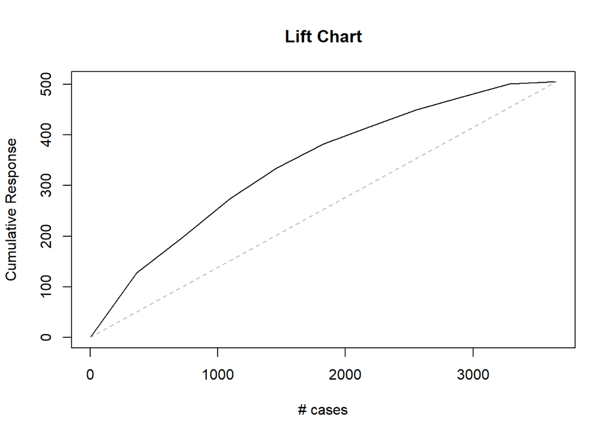

```r
gains <- gains(insurance[valid.index,]$New.Response, logit.pred.step)
response <- insurance[valid.index, ]$New.Response


plot(c(0,gains$cume.pct.of.total*sum(response))~c(0,gains$cume.obs),
     xlab="# cases", ylab="Cumulative Response", main="Lift Chart", type="l")
lines(c(0,sum(response))~c(0,dim(insurance[valid.index,])[1]), col="gray", lty=2)
```

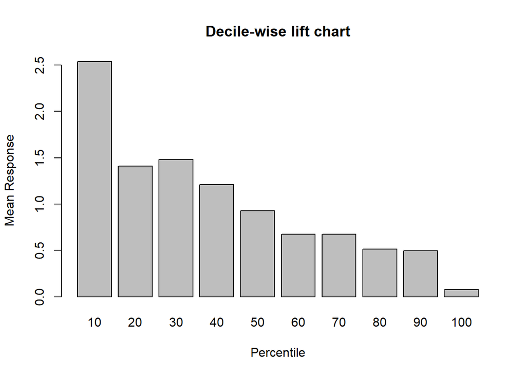

```r
barplot(gains$mean.resp/mean(response), names.arg = gains$depth,
        xlab = "Percentile", ylab = "Mean Response", main = "Decile-wise lift chart")
```